# Analysis of Activity Monitor

##### Report from Amanda Huberfeld

### Analyzing the Data

#### Loading and preprocessing the data

Download and unzip the CSV file.

```r
download.file("https://d396qusza40orc.cloudfront.net/repdata%2Fdata%2Factivity.zip",
              "activity.zip")
unzip("activity.zip")
```

#### What is mean total number of steps taken per day?

Divide the information into the categories of “steps”, “date”, and “interval”.

```r
header<-c("steps", "date", "interval")
myData <-read.csv("activity.csv", header = TRUE, col.names = header)
```

Convert the information in the dates column into parse-able dates.

```r
myData$date <- as.Date(myData$date, format = "%Y-%m-%d")
myData$interval <- as.factor(myData$interval)
```

Create a histogram of the total number of steps taken each day.

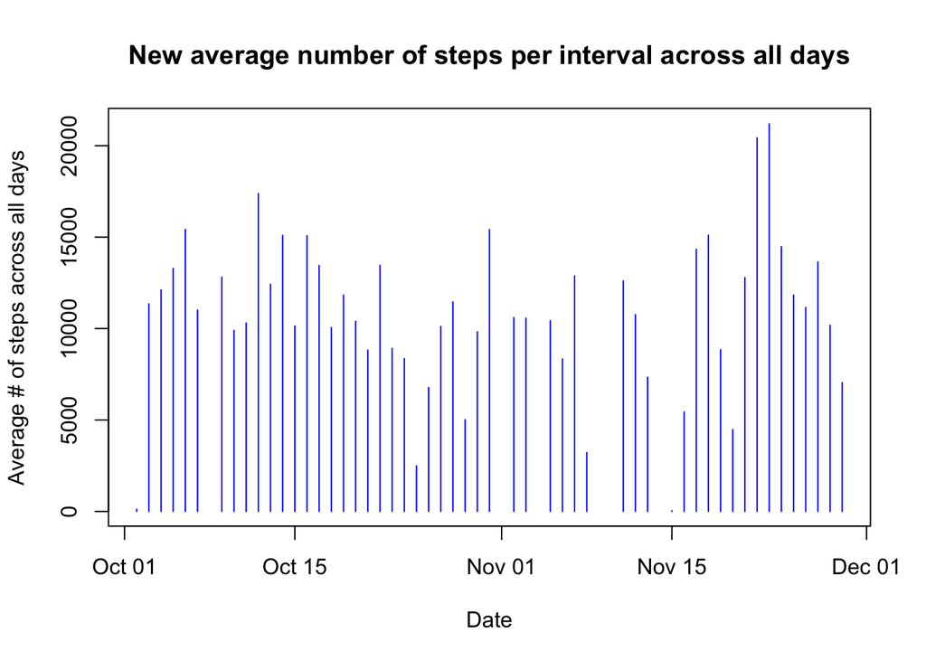

```r
stepsPerDay <- aggregate(steps ~ date, myData, sum)
colnames(stepsPerDay) <- c("date","steps")

plot(stepsPerDay, type = "h", main = "New average number of steps per interval across all days",
     xlab = "Date", ylab = "Average # of steps across all days", lwd = 1,
     col = "blue")
```

Find the mean and median of the steps per day.

```r
stepsMean   <- mean(stepsPerDay$steps, na.rm=TRUE)
stepsMedian <- median(stepsPerDay$steps, na.rm=TRUE)
print(stepsMean)
```

```
## [1] 10766.19
```

```r
print(stepsMedian)
```

```
## [1] 10765
```

#### What is the average daily activity pattern?

Plot the the average number of steps per interval in a time series plot.

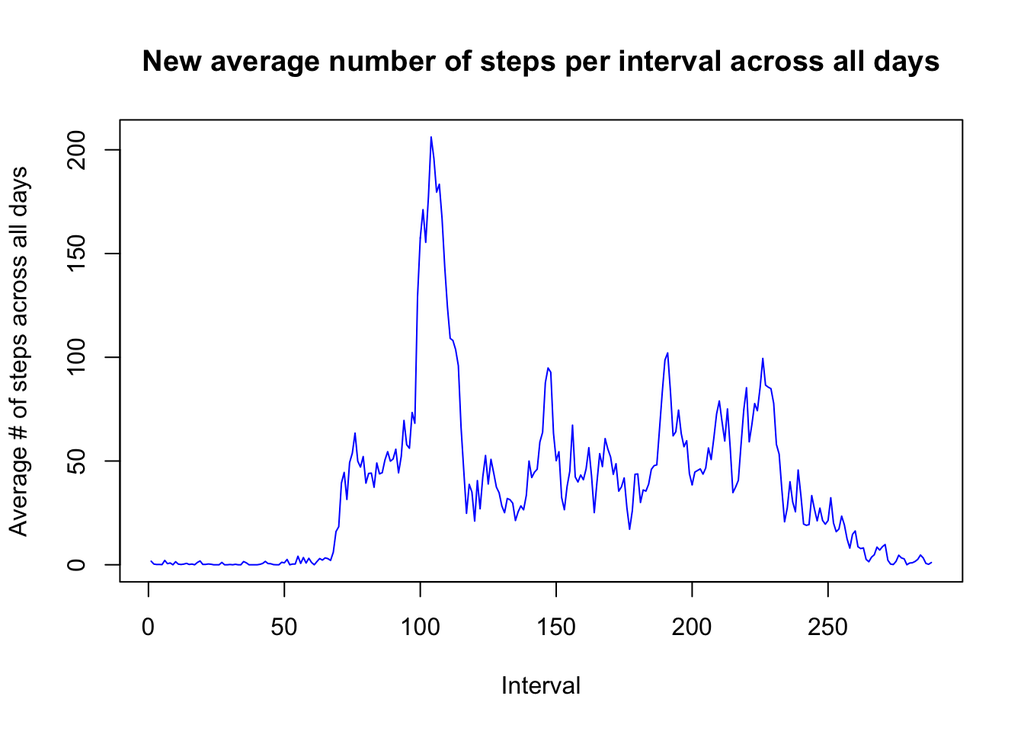

```r
intervalSplit <- split(myData$steps, myData$interval)
stepsPerInterval <- sapply(intervalSplit, mean, na.rm = TRUE)

plot(stepsPerInterval, type = "l", main = "New average number of steps per interval across all days",
     xlab = "Interval", ylab = "Average # of steps across all days", lwd = 1,
     col = "blue")
```

```r
maxInterval <- max(stepsPerInterval, na.rm = TRUE)
print(maxInterval)
```

```
## [1] 206.1698
```

### Calculating the missing values

#### Total number of missing values

Calculate the total number of intervals for which we don’t have information.

```r
missingVals <- sum(is.na(myData$steps))
print(missingVals)
```

```
## [1] 2304
```

```r
na_fill <- function(data, pervalue) {
  na_index <- which(is.na(data$steps))
  na_replace <- unlist(lapply(na_index, FUN=function(idx){
    interval = data[idx,]$interval
    pervalue[pervalue$interval == interval,]$steps
  }))
  fillSteps <- data$steps
  fillSteps[na_index] <- na_replace
  fillSteps
}
```

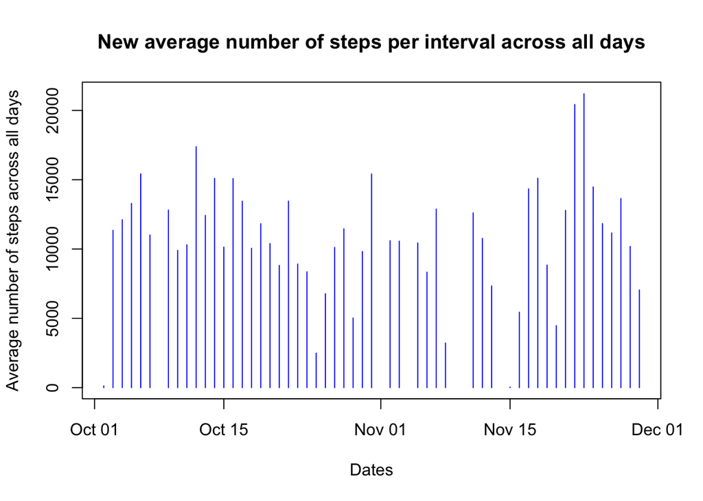

```r
newStepsPerDay <- aggregate(steps ~ date, myData, sum)
colnames(newStepsPerDay) <- c("date","steps")

plot(newStepsPerDay, type = "h", main = "New average number of steps per interval across all days",
     xlab = "Dates", ylab = "Average number of steps across all days", lwd = 1,
     col = "blue")
```

Recalculate the mean and median.

```r
newStepsMean   <- mean(newStepsPerDay$steps, na.rm=TRUE)
newStepsMedian <- median(newStepsPerDay$steps, na.rm=TRUE)
print(newStepsMean)
```

```
## [1] 10766.19
```

```r
print(newStepsMedian)
```

```
## [1] 10765
```

### Weekday versus weekend

Calculate the average steps per interval for weekdays and weekends. First, divide days into their respective days of the week.

```r
weekdaysSteps <- function(data) {
    weekdaysSteps <- aggregate(data$steps, by=list(interval = data$interval),
                          FUN=mean, na.rm=T)
    weekdaysSteps$interval <- as.integer(levels(weekdaysSteps$interval)[weekdaysSteps$interval])
    colnames(weekdaysSteps) <- c("interval", "steps")
    weekdaysSteps
}
```

Divide those days into two categories: weekday and weekend. Put them together so that they can be analyzed side by side.

```r
dataByWeekdays <- function(data) {
    data$weekday <-
            as.factor(weekdays(data$date)) # weekdays
    weekendData <- subset(data, weekday %in% c("Saturday","Sunday"))
    weekdayData <- subset(data, !weekday %in% c("Saturday","Sunday"))

    weekend_steps <- weekdaysSteps(weekendData)
    weekday_steps <- weekdaysSteps(weekdayData)

    weekend_steps$dayofweek <- rep("weekend", nrow(weekend_steps))
    weekday_steps$dayofweek <- rep("weekday", nrow(weekday_steps))

    dataByWeekdays <- rbind(weekend_steps, weekday_steps)
    dataByWeekdays$dayofweek <- as.factor(dataByWeekdays$dayofweek)
    dataByWeekdays
}

dataWeekdays <- dataByWeekdays(myData)
```

Plot both charts for comparison. Use the ggplot package so that you can fully compare the charts side by side.

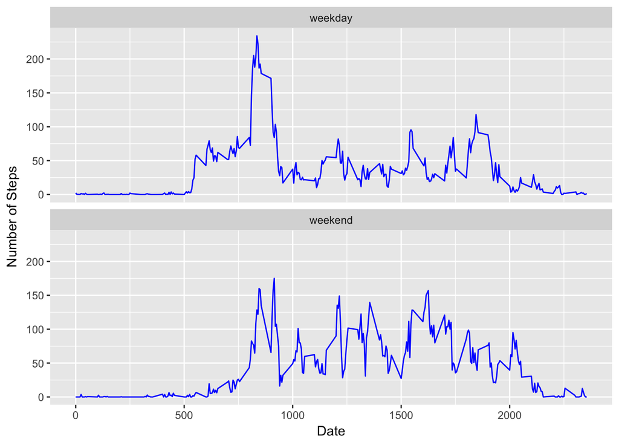

```r
ggplot(dataWeekdays, aes(x=interval, y=steps)) +
geom_line(color="blue") +
facet_wrap(~ dayofweek, nrow=2, ncol=1) +
labs(x="Date", y="Number of Steps")
```